# Project 2

Ipsita Datta & Victoria Seng

10/15/2021

# Predicting News Article Popularity

## Introduction

This data set contains a selection of news articles in six different channels, along with attributes about those articles. Our goal is to fit and test the best model using the variables provided to predict the response, number of shares, for future articles.

Predictors include day of the week on which the article was published, keywords in the title and body, videos and images in the article, polarity (positive and negative) of the title and content, and more.

We will do some exploratory analysis of the variables and fit four models: two linear regression models, and two ensemble tree-based models, a random forest and a boosted tree.

### Links to Channel Reports

- Business
- Entertainment
- Lifestyle
- Social Media
- Technology
- World News

## Data

First, we import the news popularity data csv. We’ll also pull the channel names for later use.

```r
newsPop <- read_csv("./Data/OnlineNewsPopularity.csv")

channel <- newsPop %>%
  select(starts_with("data_channel_is_")) %>%
    names
```

Next, we subset the channel for use in the initial EDA and model fitting.

```r
newsTP <- newsPop %>%
  pivot_longer(starts_with("data_channel_is_"), names_to = "chname", values_to = "v") %>%
    filter(v == TRUE) %>%
      mutate(channel = chname) %>%
        select(-chname, -v)
```

```r
subNews <- newsTP %>%
  filter(channel == params$channel) %>%
    select(-starts_with("data_channel_is_"), -url, -timedelta, -channel)
```

## Summaries

For the first few summaries, we will use this transposed data that turns the binary weekday variables into one categorical variable.

```r
TP <- subNews %>%
  pivot_longer(starts_with("weekday_is"), names_to = "wd", values_to = "wdVal") %>%
    filter(wdVal == TRUE) %>%
      mutate(weekday = substr(wd, 12, nchar(wd))) %>%
        select(-wd, -wdVal)
```

This contingency table shows the overall number of shares by weekday. A higher number means more shares have happened on that day.

```r
GDAtools::wtable(TP$weekday, w = TP$shares)
```

```
##    friday    monday  saturday    sunday  thursday   tuesday wednesday       Sum
##   1966657   4482214   1075736   1215518   3560327   3466021   3401897  19168370
```

Here is the contingency table for best keywords shares by weekdays

```r
GDAtools::wtable(TP$weekday, w = TP$kw_max_max)
```

```
##     friday     monday   saturday     sunday   thursday    tuesday  wednesday
##  621229600  860841600  181677500  258820700  907211600  879178400  939551600
##        Sum
## 4648511000
```

Here is contingency table for the number of maximum shares of an article that was linked in the article by weekday

```r
GDAtools::wtable(TP$weekday, w = TP$self_reference_max_shares)
```

```
##    friday    monday  saturday    sunday  thursday   tuesday wednesday       Sum
##   8581966  12593525   1713004   2008317  12859706  13292569  14414037  65463124
```

Here are some summary stats by weekday. Again, bigger means more shares.

```r
TP %>%
  group_by(weekday) %>%
    summarize(min = min(shares), mean = mean(shares), median = median(shares), iqr = IQR(shares), max = max(shares))
```

```
## # A tibble: 7 x 6
##   weekday     min  mean median   iqr    max
##   <chr>     <dbl> <dbl>  <dbl> <dbl>  <dbl>
## 1 friday       22 2364.   1400 1420. 102200
## 2 monday        1 3887.   1400 1651  690400
## 3 saturday    150 4427.   2600 2150  144400
## 4 sunday      692 3544.   2200 2400   56900
## 5 thursday     81 2885.   1300 1297. 306100
## 6 tuesday      44 2932.   1300 1387  310800
## 7 wednesday    63 2677.   1300 1312  158900
```

A higher number means more best keywords tend to be shared more often by weekday

```r
TP %>%
  group_by(weekday) %>%
    summarize(min = min(kw_max_max), mean = mean(kw_max_max), median = median(kw_max_max), stddev=sd(kw_max_max),iqr = IQR(kw_max_max), max = max(kw_max_max))
```

```
## # A tibble: 7 x 7
##   weekday     min    mean median  stddev    iqr    max
##   <chr>     <dbl>   <dbl>  <dbl>   <dbl>  <dbl>  <dbl>
## 1 friday    28000 746670. 843300 220859.      0 843300
## 2 monday        0 746610. 843300 218158. 152900 843300
## 3 saturday  37400 747644. 843300 204422. 152900 843300
## 4 sunday    37400 754579. 843300 206016.      0 843300
## 5 thursday  11100 735180. 843300 231586. 152900 843300
## 6 tuesday   17100 743806. 843300 220836. 152900 843300
## 7 wednesday 17100 739222. 843300 223310. 152900 843300
```

Transpose newsPop data to create pie chart across all the data channels

```r
newsPop_TP <- newsPop %>%
  pivot_longer(starts_with("data_channel_is_"), names_to = "dc", values_to = "dcVal") %>%
    filter(dcVal == TRUE) %>%
      mutate(datachannel = substr(dc, 17, nchar(dc))) %>%
        select(datachannel,shares,-dc, -dcVal)
```

Here is the pie chart showing overall which datachannel is doing best

```r
df<-newsPop_TP %>% group_by(datachannel) %>% summarise_each(funs(sum))
```

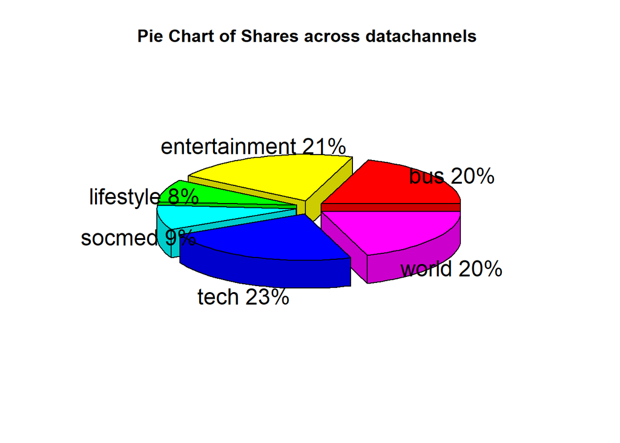

```r
pct <- round(df$shares/sum(df$shares)*100)
lbls <- paste(df$datachannel, pct) # add percents to labels
lbs<-paste(lbls,"%",sep="")
pie3D(df$shares,labels=lbs,explode=0.1,
   main="Pie Chart of Shares across datachannels ")
```

Here is the bar plot showing best keyword shares by weekdays. Higher means for best keyword shares on that day

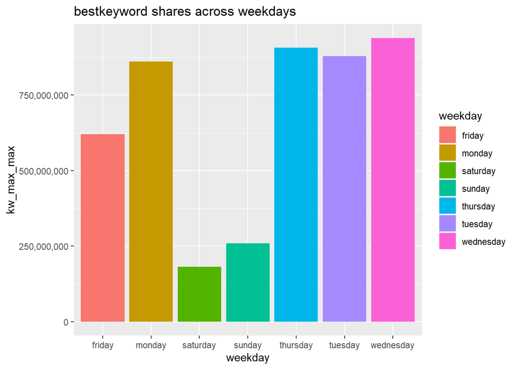

```r
plot1<-ggplot(TP,aes(x=weekday,y=kw_max_max,fill=weekday))
plot1+ geom_col() +
  scale_x_discrete("weekday") +
  ggtitle("bestkeyword shares across weekdays")+
  scale_y_continuous(labels = scales::comma)
```

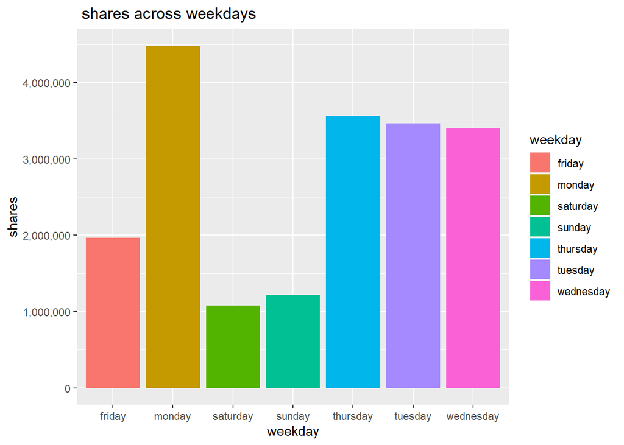

```r
plot2<-ggplot(TP,aes(x=weekday,y=shares,fill=weekday))
plot2+ geom_col() +
  scale_x_discrete("weekday") +
  ggtitle(" shares across weekdays")+
  scale_y_continuous(labels = scales::comma)
```

Here is a boxplot with jitter of shares by weekend status. The lines on the box plot show quartile values by weekend status.

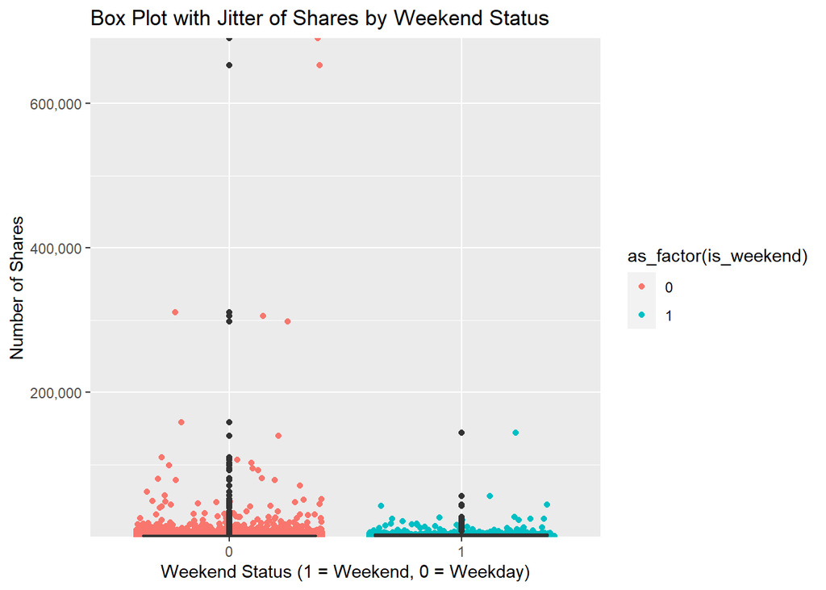

```r
g <- ggplot(data = subNews, aes(x = as_factor(is_weekend), y = shares, group = as_factor(is_weekend)))
g + geom_jitter(aes(color = as_factor(is_weekend))) +
  geom_boxplot() +
      labs(x = "Weekend Status (1 = Weekend, 0 = Weekday)",
           y = "Number of Shares",
           title = "Box Plot with Jitter of Shares by Weekend Status") +
        scale_y_continuous(labels = scales::comma, expand = expansion(mult = c(0,0)))
```

Here is a scatter plot of shares vs positive word rate with a grouping on weekday/weekend. The Y axis represents shares. More points higher on the Y axis on the lefthand side of the graph indicate less positive articles getting more shares. More points higher on the Y axis on the righthand side of the graph indicate more positive articles getting more shares. The prevelence of one color over another in any part of the graph is indicative of whether the article was published on a weekday or a weekend.

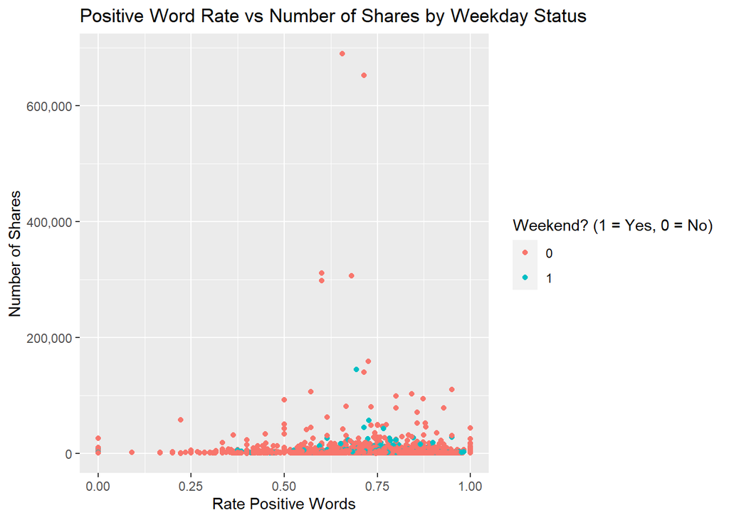

```r
g <- ggplot(data = subNews, aes(rate_positive_words, shares))
g + geom_point(aes(color = as_factor(is_weekend)), position = "jitter") +
  labs(x = "Rate Positive Words",
       y = "Number of Shares",
       title = "Positive Word Rate vs Number of Shares by Weekday Status",
       color = "Weekend? (1 = Yes, 0 = No)") +
    scale_y_continuous(labels = scales::comma)
```

Here is the scatterplot showing number of images vs shares. From the graph , we can say less number of images have more shares. Specifically those articles has zero or one image.

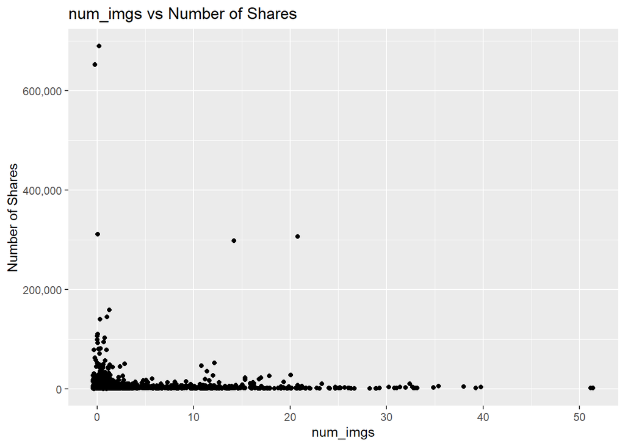

```r
g <- ggplot(data = subNews, aes(num_imgs, shares))
g + geom_point( position = "jitter") +
  labs(x = "num_imgs",
       y = "Number of Shares",
       title = "num_imgs vs Number of Shares "
       ) +
    scale_y_continuous(labels = scales::comma)
```

Here is a scatter plot of shares vs negative word rate with a grouping on weekday/weekend. The Y axis represents shares. More points higher on the Y axis on the lefthand side of the graph indicate less negative articles getting more shares. Less points higher on the Y axis on the righthand side of the graph indicate more negative articles getting less shares. The prevelence of one color over another in any part of the graph is indicative of whether the article was published on a weekday or a weekend.

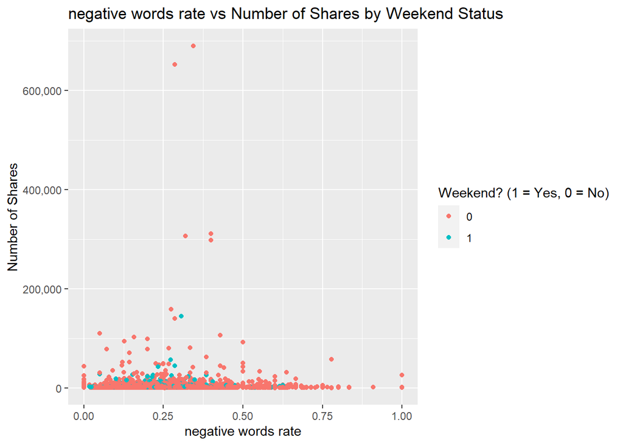

```r
g1 <- ggplot(data = subNews, aes(rate_negative_words, shares))
g1 + geom_point(aes(color = as_factor(is_weekend)), position = "jitter") +
  labs(x = "negative words rate",
       y = "Number of Shares",
       title = "negative words rate vs Number of Shares by Weekend Status",
       color = "Weekend? (1 = Yes, 0 = No)") +
    scale_y_continuous(labels = scales::comma)
```

Here is the scatter plot showing points in the middle has more share as a function of number of words in the title. On Left of the graph with less word in the title has less share by weekdays

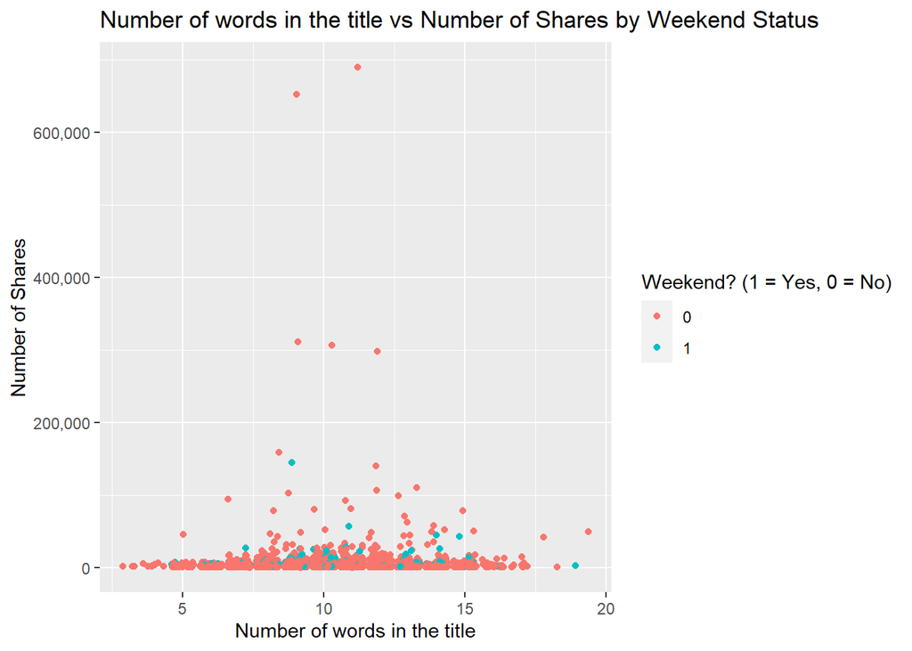

```r
g2 <- ggplot(data = subNews, aes(n_tokens_title, shares))
g2 + geom_point(aes(color = as_factor(is_weekend)), position = "jitter") +
  labs(x = "Number of words in the title",
       y = "Number of Shares",
       title = "Number of words in the title vs Number of Shares by Weekend Status",
       color = "Weekend? (1 = Yes, 0 = No)") +
    scale_y_continuous(labels = scales::comma)
```

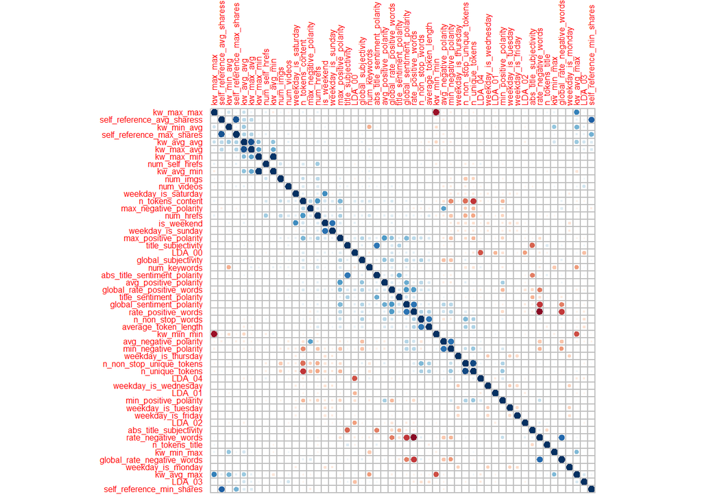

```r
c <- cor(subNews %>% select(-shares))
cp <- corrplot(c, order = 'AOE', cl.pos = 'n', tl.cex = 0.5)
```

## Model Fitting

A linear regression model describes the relationship between a dependent variable and one or more independent variables, i.e y=beta0+beta1 * x1+beta2 * x2 +….+betan * xn where y is dependent response variable and x1 to xn are independent variable (also called predictors)

Linear models are a way of describing a response variable in terms of a linear combination of predictor variables.

### First Linear Model

splitting data in train(70%) and test (30%)

```r
Index <- createDataPartition(y = subNews$shares , p= 0.7, list = FALSE)
Train <- subNews[Index,]
Test <- subNews[-Index,]
```

Performance on Test data set for Linear Regression model

```r
pred <- predict(lmfit, newdata =Test)
lm_Test<-round(postResample(pred, obs = Test$shares),4)
```

### Second Linear Model

This linear regression model chooses its predictors based on excluding any variable that has a correlation coefficient of above 0.3 or below -0.3 with any other variable. This should choose variables for each channel.

```r
cTib <- as_tibble(c) %>%
  mutate(v1 = names(as_tibble(c))) %>%
    pivot_longer(cols = !v1, names_to = "v2", values_to = "corr") %>%
      filter(abs(corr) > 0.3 & v1 != v2)

exclude <- distinct(cTib, v1) %>%
  unlist() %>%
    unname()

vChan <- subNews %>%
  select(-all_of(exclude))

vIndex <- createDataPartition(y =vChan$shares , p= 0.7, list = FALSE)
vTrain <- vChan[vIndex,]
vTest <- vChan[-vIndex,]
```

This is the model. It is pre-processed with centering and scaling and it uses 10-fold CV. The variables involved may vary from channel to channel as described above.

```r
vMod <- train(
  shares ~ .,
  data = vTrain,
  method = "lm",
  preProcess = c("center","scale"),
  trControl = trainControl(method = "cv", number = 10)
)

vPred <- predict(vMod, newdata = vTest)
v_linreg<-round(postResample(vPred, obs = vTest$shares), 4)
round(postResample(vPred, obs = vTest$shares), 4)
```

```
##      RMSE  Rsquared       MAE
## 7097.6791    0.0127 2532.4479
```

### Random Forest model

A random forest model is a supervised learning algorithm which extend the idea of bagging method to solve regression or classification problems. It creates multiple trees from bootstrap samples like as bagging method and then use a random subset of predictors for each bootstrap sample/tree fit. It doesn’t use all the predictor.

```r
randomforestFit <- train(
               shares ~ .,
               data = Train,
               method = "rf",
               preProcess = c("center", "scale"),
               trControl = trainControl(method = "cv",number = 5),
               tuneGrid = data.frame(mtry = seq(1,10,1)))
```

Performance on Test data set for Randomforest model

```r
pred <- predict(randomforestFit, newdata =Test)
rf_test<-round(postResample(pred, obs = Test$shares),4)
```

### Boosted tree model

```r
vBoost <- train(
  shares ~ .,
  data = Train,
  method = "gbm",
  preProcess = c("center", "scale"),
  trControl = trainControl(method = "repeatedcv", number = 5, repeats = 3)
)
```

Trying out the boosted tree model on the test data.

```r
pr <- predict(vBoost, newdata = Test)
boostTest <-round(postResample(pr, obs = Test$shares), 4)
```

## Comparison

We have created 4 models - 2 linear regression model,1 Random Forest Model and 1 Boosted tree model. Here in this given data set, we are trying to predict the number of shares of a news article . We are comparing four model with respect to their RMSE. Model with lowest RMSE works best.

```r
tab<-matrix(round(c(lm_Test[1],v_linreg[1],rf_test[1],boostTest[1]),1))

colnames(tab) <- c('RMSE')
rownames(tab) <- c('LM1','LM2','RandomForest','Boosted')
print(tab)
```

```
##                RMSE
## LM1          6603.6
## LM2          7097.7
## RandomForest 6350.4
## Boosted      7146.7
```

## Automation

The render code is run from readme_render_p2.R

Here is the un-evaluated render code:

```r
## The render code to output the .md files

library(tidyverse)

newsPop <- read_csv("./Data/OnlineNewsPopularity.csv")

channel <- newsPop %>%
  select(starts_with("data_channel_is_")) %>%
  names

out <- paste0(channel, ".md")
params <- lapply(channel, FUN = function(x){list(channel = x)})

docs <- tibble(out, params)

apply(
  docs,
  MARGIN = 1,
  FUN = function(x){
    rmarkdown::render(input = "./README.Rmd",
                      output_file = x[[1]],
                      output_format = "github_document",
                      output_dir = "./",
                      output_options = list(
                        toc = FALSE,
                        html_preview = FALSE,
                        keep_html = FALSE
                      ),
                      params = x[[2]]
    )
  }
)
```